# OCN 750 HW 12 - Revisiting Heat Shock

Maia Kapur

Thursday, November 12, 2015

#### Fit a GLMM that incorporates random effects for isofemale and population, and also includes fixed effects and interactions that test the 6 questions. We also need to account for potential overdispersion in the binomial response. The best way to do this in lme4 is with an ‘individual level random effect’. The thing to do is make a new factor where each row of the dataset gets a level. This is done in the replicateID column which is just a single number as a factor that gets popped into the dataframe. Other ways of doing this include the seq() function.

```r
require(lme4)
require(car)
require(effects)
require(lattice)
heat = read.csv("heat_shock_all.csv")
heat$replicateID = factor(1:nrow(heat))
#heat$proportion[heat$proportion != 0] <- 1 ## change any positive proportion of survivorship to 1
mod1  = glmer(proportion  ~  (1|isofemale) + (1|population) + sex + region + treatment + treatment*region + treatment*sex + sex*region + (1|replicateID),  data = heat, family = "binomial")
summary(mod1)
```

```
Generalized linear mixed model fit by maximum likelihood (Laplace Approximation) ['glmerMod']
 Family: binomial  ( logit )
Formula: proportion ~ (1 | isofemale) + (1 | population) + sex + region +
    treatment + treatment * region + treatment * sex + sex *      region + (1 | replicateID)
   Data: heat

     AIC      BIC   logLik deviance df.resid
   479.0    532.8   -229.5    459.0     1600

Scaled residuals:
    Min      1Q  Median      3Q     Max
-0.2872 -0.1111  0.0966  0.8578  9.1713

Random effects:
 Groups      Name        Variance  Std.Dev.
 replicateID (Intercept) 7.124e-08 0.0002669
 isofemale   (Intercept) 3.662e-08 0.0001914
 population  (Intercept) 0.000e+00 0.0000000
Number of obs: 1610, groups:  replicateID, 1610; isofemale, 56; population, 9

Fixed effects:
                                   Estimate Std. Error z value Pr(>|z|)
(Intercept)                         -4.4986     0.7311  -6.154 7.58e-10 ***
sexMales                            -1.3257     1.0087  -1.314   0.1887
regionSouthwest                      0.4030     0.8371   0.481   0.6302
treatmenthardening                   1.3809     0.8214   1.681   0.0927 .
regionSouthwest:treatmenthardening   0.2198     0.9241   0.238   0.8120
sexMales:treatmenthardening          0.2754     0.7351   0.375   0.7080
sexMales:regionSouthwest             1.0273     0.8635   1.190   0.2341
---
Signif. codes:  0 â***â 0.001 â**â 0.01 â*â 0.05 â.â 0.1 â â 1

Correlation of Fixed Effects:
            (Intr) sexMls rgnSth trtmnt rgnSt: sxMls:
sexMales    -0.235
reginSthwst -0.827  0.007
trtmnthrdnn -0.850  0.041  0.688
rgnSthwst:t  0.704  0.186 -0.851 -0.827
sxMls:trtmn  0.140 -0.594  0.212 -0.164 -0.227
sxMls:rgnSt  0.176 -0.749 -0.213  0.068 -0.064 -0.011
convergence code: 0
Model failed to converge with max|grad| = 0.00636713 (tol = 0.001, component 1)
```

```r
## Only intercept (sexFemales) and the treatment are significant (treatment only marginally so.) New model drops all interaction terms and includes random effects.
```

[output not shown]

```r
summary(mod2)
```

```
Generalized linear mixed model fit by maximum likelihood (Laplace Approximation) ['glmerMod']
 Family: binomial  ( logit )
Formula: proportion ~ (1 | isofemale) + (1 | population) + (1 | replicateID) +      treatment + sex
   Data: heat

     AIC      BIC   logLik deviance df.resid
   480.4    512.7   -234.2    468.4     1604

Scaled residuals:
    Min      1Q  Median      3Q     Max
-0.2671 -0.1150  0.1868  0.9361  6.5986

Random effects:
 Groups      Name        Variance Std.Dev.
 replicateID (Intercept) 0        0
 isofemale   (Intercept) 0        0
 population  (Intercept) 0        0
Number of obs: 1610, groups:  replicateID, 1610; isofemale, 56; population, 9

Fixed effects:
                   Estimate Std. Error z value Pr(>|z|)
(Intercept)         -4.3265     0.3414 -12.672  < 2e-16 ***
treatmenthardening   1.6864     0.3513   4.800 1.59e-06 ***
sexMales            -0.1701     0.2705  -0.629    0.529
---
Signif. codes:  0 â***â 0.001 â**â 0.01 â*â 0.05 â.â 0.1 â â 1

Correlation of Fixed Effects:
            (Intr) trtmnt
trtmnthrdnn -0.841
sexMales    -0.363 -0.009
```

#### Plot the fitted fixed effects using the effects package. How do you interpret these results, in light of the 6 questions listed above? MK note on 11/7/16: allEffects plots sometimes get squished. I coerce these to be big enough by using fig.width = and fig.height = in the brackets at the code header.

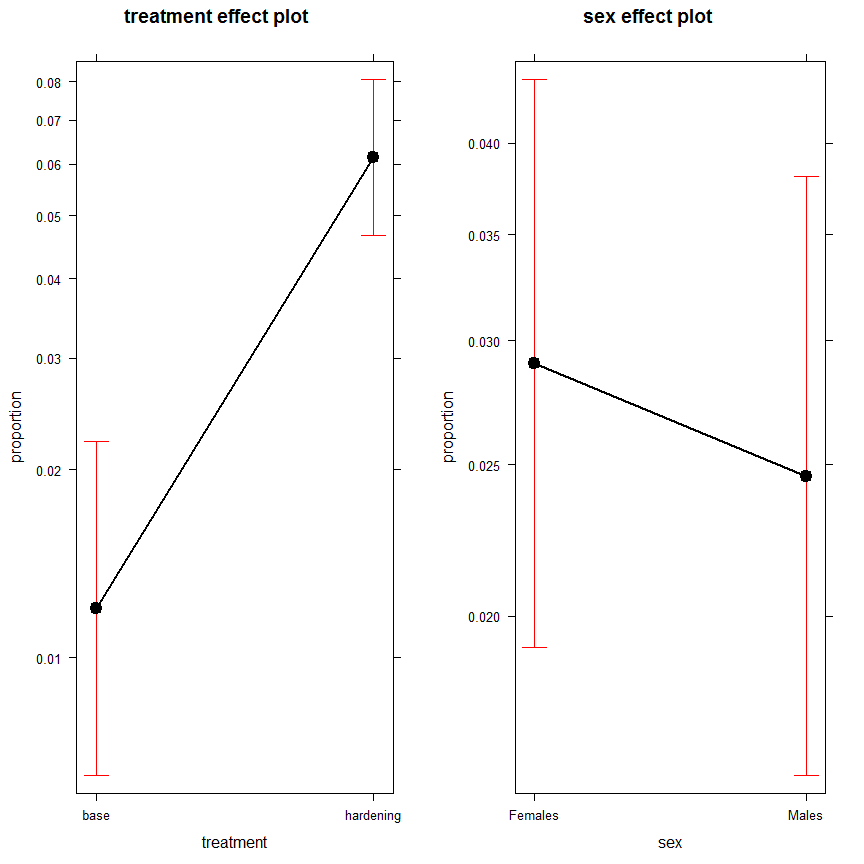

#### Use the random effects estimates, and dotplot() of those estimates, to discuss how much genetic variation there is among populations, and among isofemales within populations, and how much extra (overdispersed) variation there is among replicates. Plotting the individual-level random effect for replicate is not advised; there are too many levels for the function. How does the spread for the random effects compare to the effect sizes of the fixed effects?

```r
fixef(mod2)
```

```
       (Intercept) treatmenthardening           sexMales
         -4.326499           1.686390          -0.170145
```

#### The authors were interested in another question as well: Does acclimation to high temperature (i.e., the treatment effect) exhibit genetic variation among isofemale lines? To test this, you need to allow treatment to vary by isofemale. In other words, you need to include a fixed*random interaction. Put this in the model, and use a likelihood ratio test to see if it is important. Use dotplot() to visualize how the treatment effect varies by isofemale. Does the genetic variation seem substantial? What is the correlation between the random Intercept and random treatment effect among isofemales? Can you explain what this correlation implies? Does including the treatment-by-isofemale interaction change the results for the fixed effects in the model? If so, how?

```r
mod3  = glmer(proportion  ~  (1|isofemale)  + (1|population) + (1|replicateID) + treatment + sex + (treatment|isofemale), data  = heat, family = "binomial")
summary(mod3)
```

```
Generalized linear mixed model fit by maximum likelihood (Laplace Approximation) ['glmerMod']
 Family: binomial  ( logit )
Formula: proportion ~ (1 | isofemale) + (1 | population) + (1 | replicateID) +      treatment + sex + (treatment | isofemale)
   Data: heat

     AIC      BIC   logLik deviance df.resid
   486.7    535.2   -234.4    468.7     1601

Scaled residuals:
    Min      1Q  Median      3Q     Max
-0.2666 -0.1120  0.1738  0.9394  6.6018

Random effects:
 Groups      Name               Variance  Std.Dev. Corr
 replicateID (Intercept)        1.279e-03 0.035760
 isofemale   (Intercept)        2.078e-03 0.045589
             treatmenthardening 4.054e-03 0.063671 -0.98
 isofemale.1 (Intercept)        2.510e-05 0.005010
 population  (Intercept)        3.574e-05 0.005978
Number of obs: 1610, groups:  replicateID, 1610; isofemale, 56; population, 9

Fixed effects:
                   Estimate Std. Error z value Pr(>|z|)
(Intercept)         -4.3786     0.3467 -12.628  < 2e-16 ***
treatmenthardening   1.7321     0.3552   4.876 1.08e-06 ***
sexMales            -0.1239     0.2693  -0.460    0.645
---
Signif. codes:  0 â***â 0.001 â**â 0.01 â*â 0.05 â.â 0.1 â â 1

Correlation of Fixed Effects:
            (Intr) trtmnt
trtmnthrdnn -0.843
sexMales    -0.364 -0.008
convergence code: 0
Model failed to converge with max|grad| = 0.452339 (tol = 0.001, component 1)
```

```r
anova(mod3, mod2)
```

```
Data: heat
Models:
mod2: proportion ~ (1 | isofemale) + (1 | population) + (1 | replicateID) +
mod2:     treatment + sex
mod3: proportion ~ (1 | isofemale) + (1 | population) + (1 | replicateID) +
mod3:     treatment + sex + (treatment | isofemale)
     Df    AIC    BIC  logLik deviance Chisq Chi Df Pr(>Chisq)
mod2  6 480.40 512.70 -234.20   468.40
mod3  9 486.73 535.18 -234.36   468.73     0      3          1
```

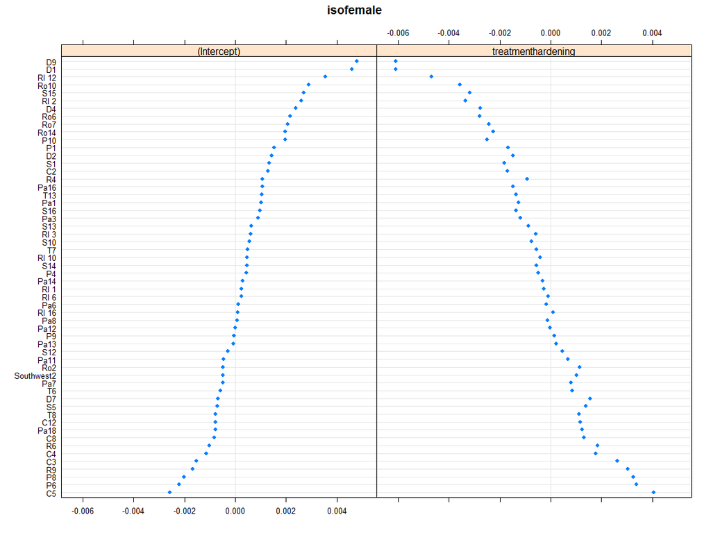

```r
dotplot(ranef(mod3))$isofemale
```

```r
# plot(fixef(mod3), fixef(mod2))
# abline(0,1)
# require(ggplot2)
# ggplot(data = NULL, aes(x = fixef(mod3), y = fixef(mod2)))+
#   geom_point() +
#   geom_abline(slope = 1, intercept = 0, lwd = 2, col = 'red') +
#   theme_bw()
## there's almost a perfect 1:1 relationship between the fixed effects for the model with and without the fixed*random interaction. So it doesn't add a very significant difference in the value.
```